# Practical Machine Learning Project

**Introduction:**

Using devices such as Jawbone Up, Nike Fuel Band, and Fit bit it is now possible to collect a large amount of data about personal activity relatively inexpensively. These type of devices are part of the quantified self movement - a group of enthusiasts who take measurements about themselves regularly to improve their health, to find patterns in their behavior, or because they are tech geeks.

One thing that people regularly do is quantify how much of a particular activity they do,but they rarely quantify how well they do it.

In this project, your goal will be to use data from accelerometers on the belt, forearm, arm and dumbell of 6 participants and predict the manner on which they did the exercise.

**Load the Data**

```r
library(caret)
library(rattle)
```

```r
#Downloading data from web and replacing missing values with NA

TrainData<- read.csv(url("https://d396qusza40orc.cloudfront.net/predmachlearn/pml-training.csv"),header=TRUE, na.strings = c("NA","",'#DIV/0!'))
dim(TrainData)
```

```
## [1] 19622   160
```

```r
TestData <- read.csv(url("https://d396qusza40orc.cloudfront.net/predmachlearn/pml-testing.csv"), header=TRUE, na.strings = c("NA","",'#DIV/0!'))
dim(TestData)
```

```
## [1]  20 160
```

```r
str(TrainData)
```

```
## 'data.frame':    19622 obs. of  160 variables:
##  $ X                       : int  1 2 3 4 5 6 7 8 9 10 ...
##  $ user_name               : Factor w/ 6 levels "adelmo","carlitos",..: 2 2 2 2 2 2 2 2 2 2 ...
##  $ raw_timestamp_part_1    : int  1323084231 1323084231 1323084231 1323084232 1323084232 1323084232 1323084232 1323084232 1323084232 1323084232 ...
##  $ raw_timestamp_part_2    : int  788290 808298 820366 120339 196328 304277 368296 440390 484323 484434 ...
##  $ cvtd_timestamp          : Factor w/ 20 levels "02/12/2011 13:32",..: 9 9 9 9 9 9 9 9 9 9 ...
##  $ new_window              : Factor w/ 2 levels "no","yes": 1 1 1 1 1 1 1 1 1 1 ...
##  $ num_window              : int  11 11 11 12 12 12 12 12 12 12 ...
##  $ roll_belt               : num  1.41 1.41 1.42 1.48 1.48 1.45 1.42 1.42 1.43 1.45 ...
##  $ pitch_belt              : num  8.07 8.07 8.07 8.05 8.07 8.06 8.09 8.13 8.16 8.17 ...
##  $ yaw_belt                : num  -94.4 -94.4 -94.4 -94.4 -94.4 -94.4 -94.4 -94.4 -94.4 -94.4 ...
##  $ total_accel_belt        : int  3 3 3 3 3 3 3 3 3 3 ...
##  $ kurtosis_roll_belt      : num  NA NA NA NA NA NA NA NA NA NA ...
##  $ kurtosis_picth_belt     : num  NA NA NA NA NA NA NA NA NA NA ...
##  $ kurtosis_yaw_belt       : logi  NA NA NA NA NA NA ...
```

[output cut: 86 more lines]

The training data set is made of 19622 observations on 160 columns. We can notice that many columns have NA values or blank values on almost every observation.

We will remove columns with NA values, because they will not produce any information.

**Clean the Data**

```r
TrainData <- TrainData[,(colSums(is.na(TrainData)) == 0)]
dim(TrainData)
```

```
## [1] 19622    60
```

```r
TestData <- TestData[,(colSums(is.na(TestData)) == 0)]
dim(TestData)
```

```
## [1] 20 60
```

Note: We reduced the data to 60 variables.

**Preprocess the data**

```r
numericalsIdx   <- which(lapply(TrainData, class) %in% "numeric")

preprocessModel <- preProcess(TrainData[,numericalsIdx],method=c('knnImpute', 'center', 'scale'))
pre_TrainData   <- predict(preprocessModel, TrainData[,numericalsIdx])
pre_TrainData$classe <- TrainData$classe
pre_TestData    <- predict(preprocessModel,TestData[,numericalsIdx])
```

**Removing the non zero variables**

Removing the variables with values near zero, that means that they have not so much meaning in the predictions

```r
nzv <- nearZeroVar(pre_TrainData, saveMetrics=TRUE)
pre_TrainData <- pre_TrainData[,nzv$nzv==FALSE]

nzv <- nearZeroVar(pre_TestData, saveMetrics=TRUE)
pre_TestData <- pre_TestData[,nzv$nzv==FALSE]
```

**Validation set**

```r
# Here we create a partition of the traning data set
library(AppliedPredictiveModeling)

set.seed(12345)
inTrain <- createDataPartition(pre_TrainData$classe, p=0.75, list=FALSE)
Training   <- pre_TrainData[inTrain,]
Testing    <- pre_TrainData[-inTrain,]

dim(Training)
```

```
## [1] 14718    28
```

```r
dim(Testing)
```

```
## [1] 4904   28
```

**Train Model**

In the following section, we will train a model using random forest. In order to limit the effects of overfitting, and improve the efficicency of the model, we will use the *cross-validation technique* of 5 folds.

```r
library(randomForest)
trControl <- trainControl(method="cv", number=5)
modrf   <- train(classe ~., method="rf", data=Training, trControl=trControl, allowParallel=TRUE, importance=TRUE)

modrf
```

```
## Random Forest
##
## 14718 samples
##    27 predictor
##     5 classes: 'A', 'B', 'C', 'D', 'E'
##
## No pre-processing
## Resampling: Cross-Validated (5 fold)
## Summary of sample sizes: 11775, 11774, 11774, 11775, 11774
## Resampling results across tuning parameters:
##
##   mtry  Accuracy   Kappa
##    2    0.9919826  0.9898575
##   14    0.9918467  0.9896863
##   27    0.9893329  0.9865073
##
## Accuracy was used to select the optimal model using the largest value.
## The final value used for the model was mtry = 2.
```

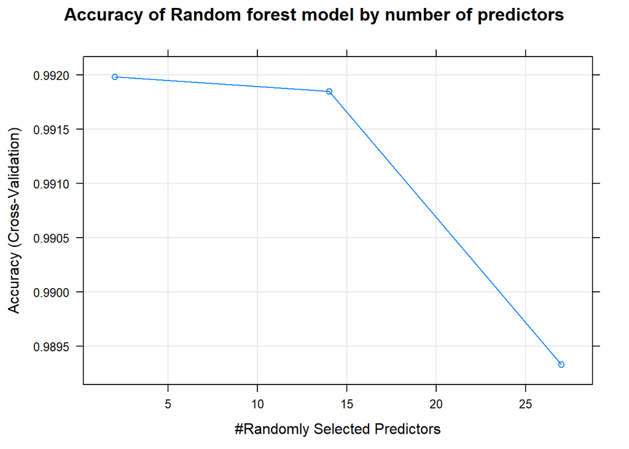

```r
plot(modrf, main ="Accuracy of Random forest model by number of predictors")
```

**Cross Validation Testing and Out-of-Sample Error Estimate**

We will apply our training model on our testing database, to check its accuracy.

Accuracy and Estimated out of sample error

```r
preValidRF <- predict(modrf, Testing)
ConMat     <- confusionMatrix(Testing$classe, preValidRF)
ConMat$table
```

```
##           Reference
## Prediction    A    B    C    D    E
##          A 1395    0    0    0    0
##          B    0  945    4    0    0
##          C    0    3  846    6    0
##          D    0    0   11  791    2
##          E    0    0    2    1  898
```

We can notice that there are very few variables out of this model.

```r
accur <- postResample(Testing$classe, preValidRF)
modAccuracy <- accur[[1]]
modAccuracy
```

```
## [1] 0.9940865
```

```r
out_of_sample_error <- 1 - modAccuracy
out_of_sample_error
```

```
## [1] 0.00591354
```

The estimated accuracy of the model is 99.4% and the estimated out of sample error based on our filter model applied to the cross validation dataset is 0.6%

**Application of this model on the 20 test cases provided**

```r
pred_final <- predict(modrf, pre_TestData)
pred_final
```

```
##  [1] B A B A A E D B A A B C B A E E A B B B
## Levels: A B C D E
```